# linc-Brn1a KO vs WT (Adult)

- other heatmap labels (csHeatmap)
- cache gsea and overlap figure!!
- tracks
- should import litter info

# Design Overview

This file shows the wt-v-ko comparison for linc-Brn1a.

Cuff overview:

```
## CuffSet instance with:
##   2 samples
##   26754 genes
##   77524 isoforms
##   0 TSS
##   23066 CDS
##   0 promoters
##   0 splicing
##   19954 relCDS
```

# QC

## Dispersion

[output not shown]

## Cross-replicate variability (fpkmSCVplot)

Differences in CV 2 can result in lower numbers of differentially expressed genes due to a higher degree of variability between replicate fpkm estimates.

Genes:

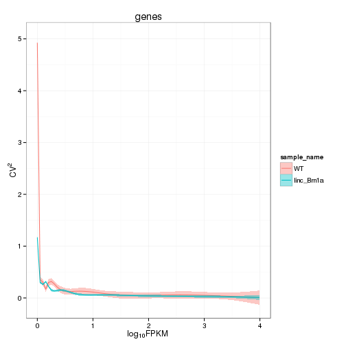

Isoforms:

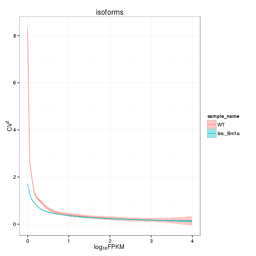

## Volcano

### Volcano matrix (replicates)

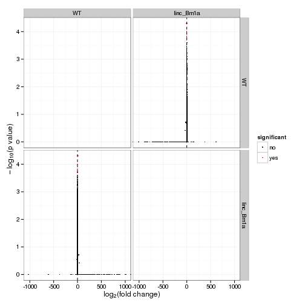

## Scatterplot

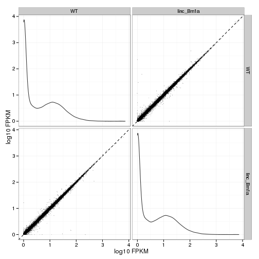

### Scatter matrix (replicates) – SKIP FOR NOW CAUSING PROBLEMS

## Distributions

### Boxplots

Boxplot (genes)

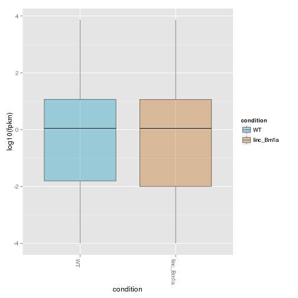

Boxplot (genes, replicates)

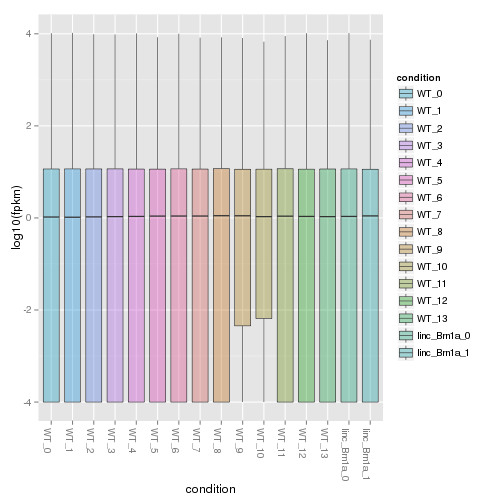

Boxplot (isoforms)

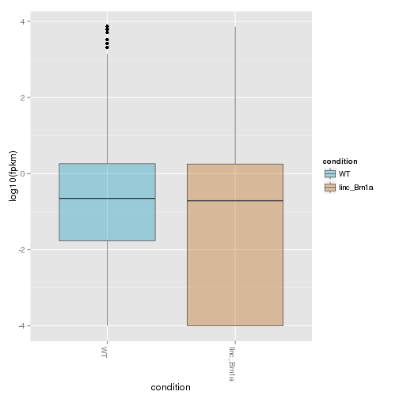

Boxplot (isoforms, replicates)

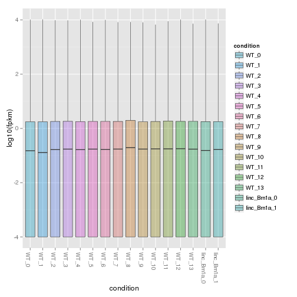

### Density

Density (genes)

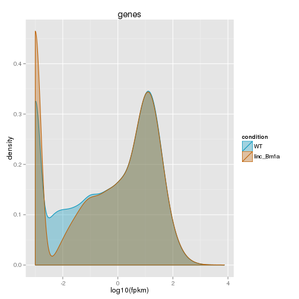

Density (genes, replicates)

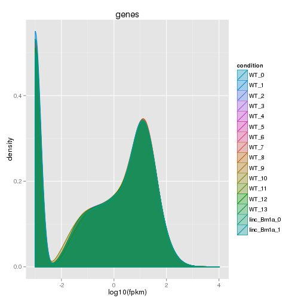

## Clustering

### Replicate Clusters

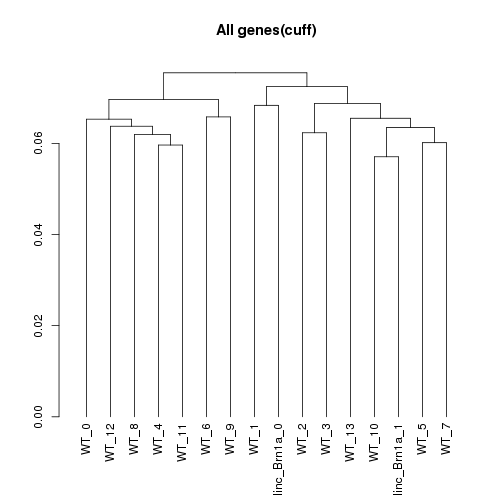

```
## 'dendrogram' with 2 branches and 16 members total, at height 0.07549
```

### PCA (genes)

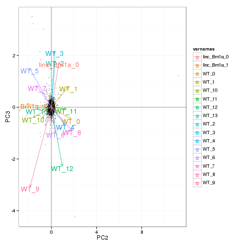

### MDS (genes)

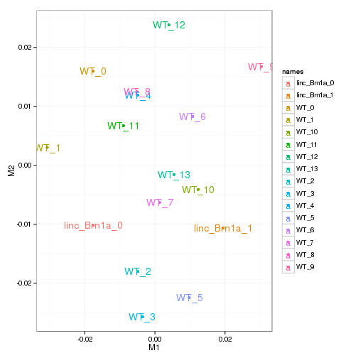

# KO assessment

## Endogenous lncRNA expression

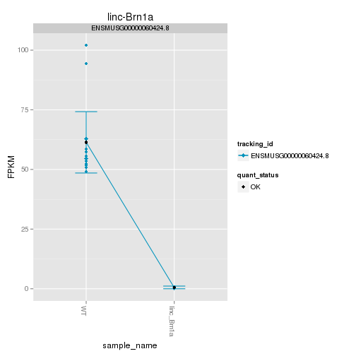

Endogenous expression of linc-Brn1a isoforms:

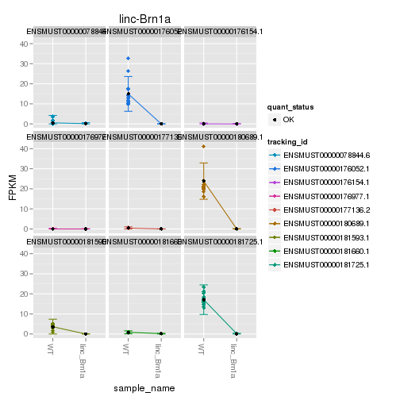

Barplot of gene expression:

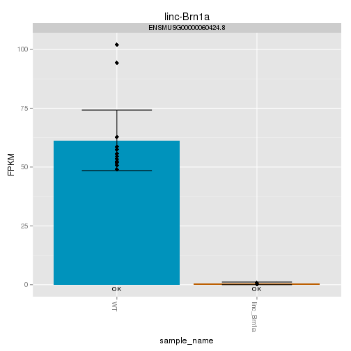

Barplot of isoform expression:

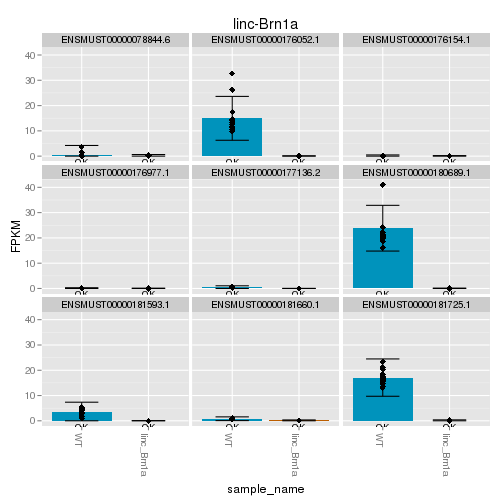

## LacZ expression

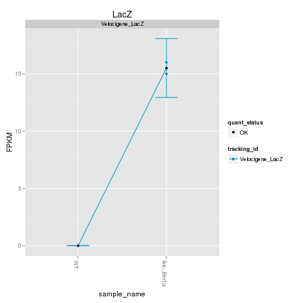

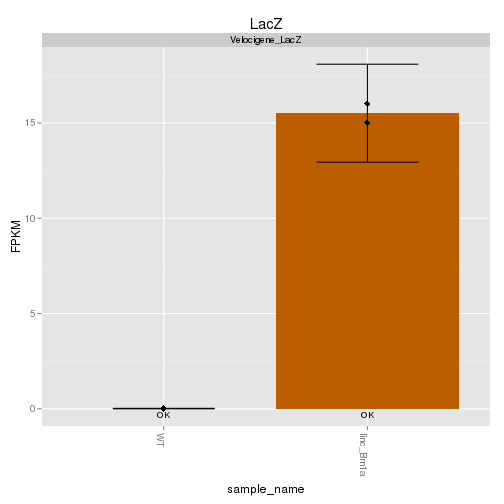

## Digital Genotyping (LacZ vs Endogenous lncRNA and Sex)

Expression plot (endogenous linc, lacZ, Y-expressed gene):

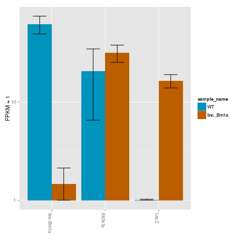

Expression heatmap:

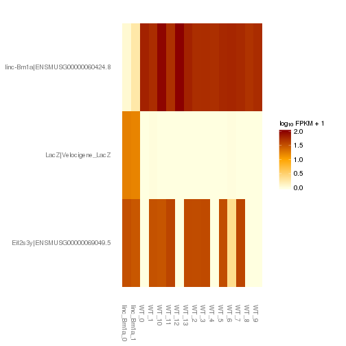

# Differential Analysis

## Differential Genes

There are 70 significantly differentially expressed genes. They are:

|  | geneAnnot$gene_short_name |
| --- | --- |
| 1 | Rec8 |
| 2 | Arrdc2 |
| 3 | Fosb |
| 4 | Dio2 |
| 5 | Mertk |
| 6 | Hspa8 |
| 7 | Vip |
| 8 | Fabp7 |
| 9 | Sgk1 |
| 10 | Mybpc1 |
| 11 | Btg2 |
| 12 | Fos |
| 13 | Rgcc |
| 14 | Arc |
| 15 | Sdf2l1 |
| 16 | Nr4a1 |
| 17 | Cdkn1a |
| 18 | Sik1 |
| 19 | Xdh |
| 20 | Dusp1 |
| 21 | Fkbp5 |
| 22 | Il33 |
| 23 | Pdia4 |
| 24 | Paqr8 |
| 25 | Tfcp2l1 |
| 26 | Hspa5 |
| 27 | Cyr61 |
| 28 | Nr4a3 |
| 29 | Alad |
| 30 | Slc2a1 |
| 31 | Mfsd2a |
| 32 | Tinagl1 |
| 33 | Adipor2 |
| 34 | Pglyrp1 |
| 35 | Hddc3 |
| 36 | Tsc22d3 |
| 37 | Cryab |
| 38 | Ndn |
| 39 | Igsf9b |
| 40 | Cbl |
| 41 | Nostrin |
| 42 | Anln |
| 43 | Tob1 |
| 44 | Egr2 |
| 45 | Smim3 |
| 46 | Egr1 |
| 47 | Hdhd3 |
| 48 | Daam2 |
| 49 | Npas4 |
| 50 | Gpr17 |
| 51 | Nrros |
| 52 | Jun |
| 53 | Junb |
| 54 | Ier2 |
| 55 | Per2 |
| 56 | Kdm5d |
| 57 | Rpl30 |
| 58 | linc-Brn1a |
| 59 | Usp31 |
| 60 | Zbtb16 |
| 61 | Ddx3y |
| 62 | Klhl9 |
| 63 | Egr4 |
| 64 | Gm7292 |
| 65 | Fat3 |
| 66 | Xist |
| 67 | Cdr1 |
| 68 | AA465934 |
| 69 | Gm6472 |
| 70 | Gm26924 |

### Matrix of gene significant differences between conditions

(skip for Brainmap wt-v-ko comparisons)

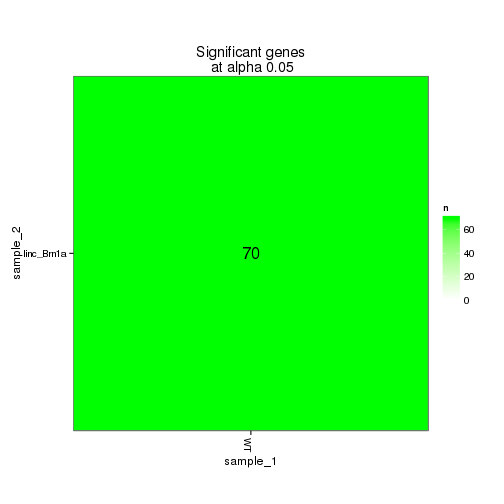

### Significant gene expression differences between conditions

Expression plot (genes):

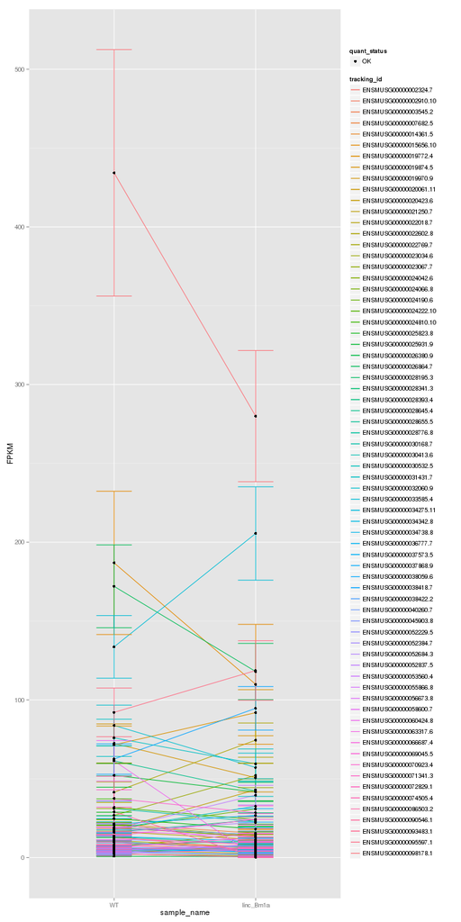

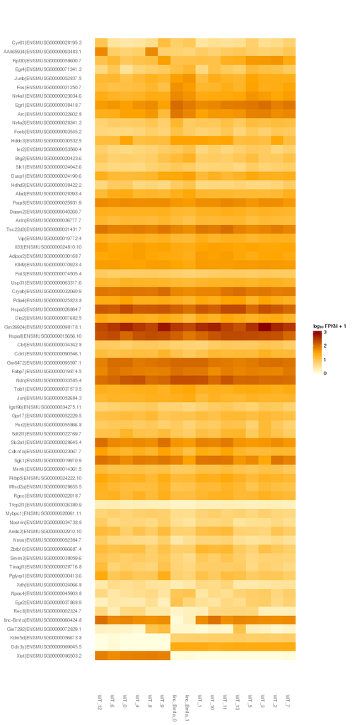

Significant genes with expression >50fpkm (any condition):

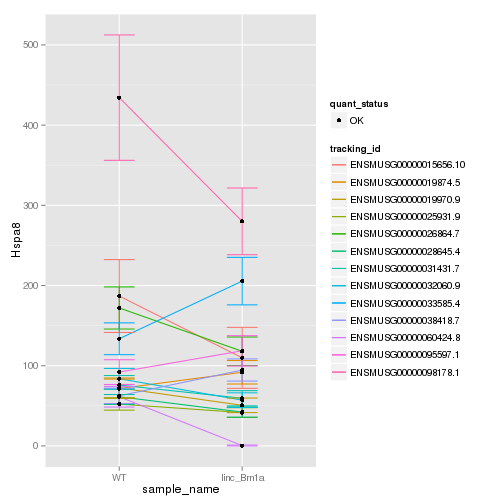

An individual look at each of the highly expressed significantly differentially regulated genes: (eval=false for first pass)

### Expression-level/significance relationship

[output not shown]

[output not shown]

## Differential Splicing

### Differential Isoforms between conditions

Per isoform difference between conditions:

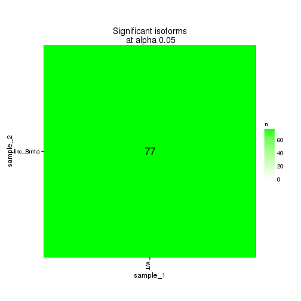

These isoforms are:

|  | isoAnnot$gene_short_name |
| --- | --- |
| 1 | Rec8 |
| 2 | Arrdc2 |
| 3 | Fosb |
| 4 | Hif3a |
| 5 | Dio2 |
| 6 | Mertk |
| 7 | Hspa8 |
| 8 | Vip |
| 9 | Fabp7 |
| 10 | Cpm |
| 11 | Btg2 |
| 12 | Xbp1 |
| 13 | Atp2a3 |
| 14 | Fos |
| 15 | Rgcc |
| 16 | Arc |
| 17 | Zbtb20 |
| 18 | Sdf2l1 |
| 19 | Nr4a1 |
| 20 | Cdkn1a |
| 21 | Sik1 |
| 22 | Xdh |
| 23 | Atp6v0c |
| 24 | Dusp1 |
| 25 | Fkbp5 |
| 26 | Il33 |
| 27 | Pdia4 |
| 28 | Paqr8 |
| 29 | Hspa5 |
| 30 | Cyr61 |
| 31 | Alad |
| 32 | Slc2a1 |
| 33 | Mfsd2a |
| 34 | Ago3 |
| 35 | Map3k6 |
| 36 | Adipor2 |
| 37 | Pglyrp1 |
| 38 | Hddc3 |
| 39 | Tsc22d3 |
| 40 | Cryab |
| 41 | Kdm4a |
| 42 | Ndn |
| 43 | Vps8 |
| 44 | Igsf9b |
| 45 | Cbl |
| 46 | Nostrin |
| 47 | Anln |
| 48 | Kirrel2 |
| 49 | Egr2 |
| 50 | Smim3 |
| 51 | Egr1 |
| 52 | Hdhd3 |
| 53 | Eltd1 |
| 54 | Daam2 |
| 55 | Dmtf1 |
| 56 | Npas4 |
| 57 | Ezr |
| 58 | Jun |
| 59 | Junb |
| 60 | Ier2 |
| 61 | Per2 |
| 62 | Kdm5d |
| 63 | Usp31 |
| 64 | Sepp1 |
| 65 | Zbtb16 |
| 66 | Ddx3y |
| 67 | Ahnak |
| 68 | Klhl9 |
| 69 | Egr4 |
| 70 | Xist |
| 71 | Slc5a3 |
| 72 | Cdr1 |
| 73 | Malat1 |
| 74 | Gm6472 |
| 75 | Gm26924 |

[output not shown]

### Differential Splicing between conditions

(eval false for first pass)

Per condition differences in isoforms (Does gene have diff piechart between conditions?)

# Gene/Pathway Analysis

## GSEA

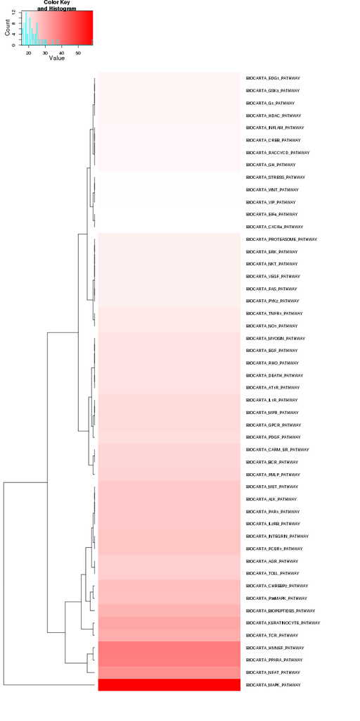

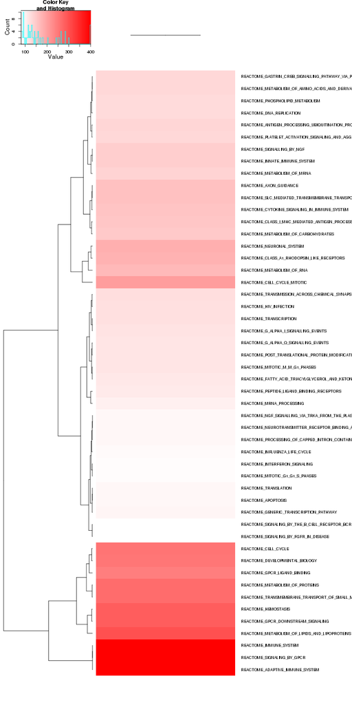

## GO enrichment

Cluster profiler used to call enichments of significantly differentially regulated genes that map to Entrez IDs.

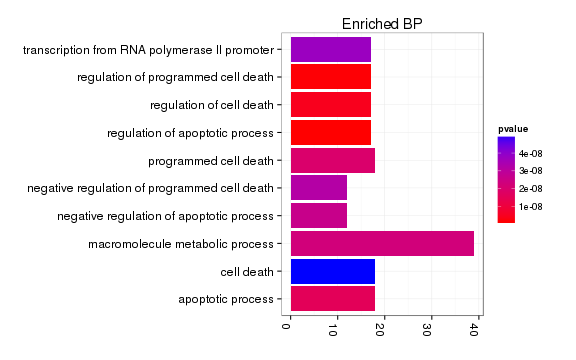

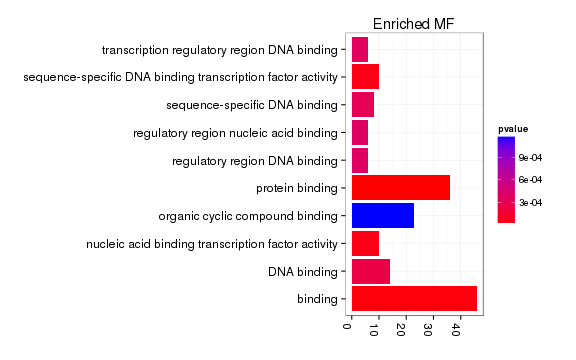

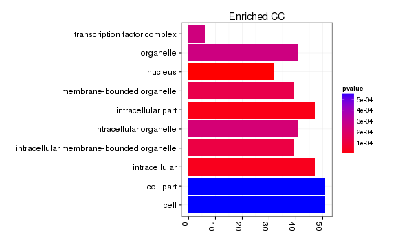

[output not shown]

[output not shown]

# Cis vs Trans (locally)

[output not shown]

The pvalue for 1 genes significantly regulated in this region is: 1

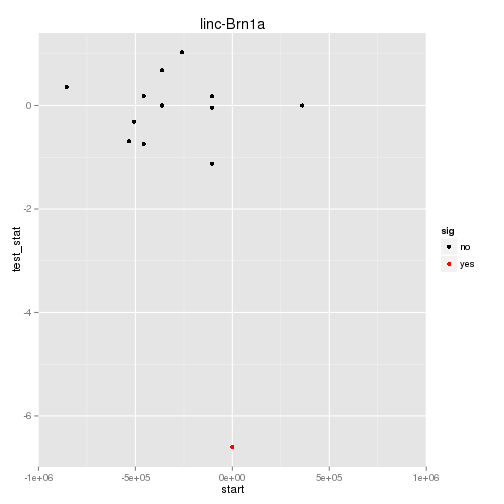

# Notes

## Samples used are:

|  | 10 |
| --- | --- |
| 1 | JR729 |
| 2 | JR728 |
| 3 | JR796 |
| 4 | JR797 |
| 5 | JR740 |
| 6 | JR800 |
| 7 | JR827 |
| 8 | JR778 |
| 9 | JR734 |
| 10 | JR802 |
| 11 | JR803 |
| 12 | JR735 |
| 13 | JR785 |
| 14 | JR781 |
| 15 | JR730 |
| 16 | JR837 |

## Replicates

|  | file | sample_name | replicate | rep_name | total_mass | norm_mass | internal_scale | external_scale |
| --- | --- | --- | --- | --- | --- | --- | --- | --- |
| 1 | /n/rinn_data1/seq/lgoff/Projects/BrainMap/data/quants/JR729/abundances.cxb | WT | 0 | WT_0 | 26338300.00 | 33761700.00 | 0.78 | 1.00 |
| 2 | /n/rinn_data1/seq/lgoff/Projects/BrainMap/data/quants/JR728/abundances.cxb | WT | 1 | WT_1 | 20332100.00 | 33761700.00 | 0.60 | 1.00 |
| 3 | /n/rinn_data1/seq/lgoff/Projects/BrainMap/data/quants/JR796/abundances.cxb | WT | 2 | WT_2 | 34093300.00 | 33761700.00 | 1.00 | 1.00 |
| 4 | /n/rinn_data1/seq/lgoff/Projects/BrainMap/data/quants/JR797/abundances.cxb | WT | 3 | WT_3 | 28111900.00 | 33761700.00 | 0.82 | 1.00 |
| 5 | /n/rinn_data1/seq/lgoff/Projects/BrainMap/data/quants/JR740/abundances.cxb | WT | 4 | WT_4 | 35813300.00 | 33761700.00 | 1.06 | 1.00 |
| 6 | /n/rinn_data1/seq/lgoff/Projects/BrainMap/data/quants/JR800/abundances.cxb | WT | 5 | WT_5 | 37017800.00 | 33761700.00 | 1.10 | 1.00 |
| 7 | /n/rinn_data1/seq/lgoff/Projects/BrainMap/data/quants/JR827/abundances.cxb | WT | 6 | WT_6 | 27790600.00 | 33761700.00 | 0.83 | 1.00 |
| 8 | /n/rinn_data1/seq/lgoff/Projects/BrainMap/data/quants/JR778/abundances.cxb | WT | 7 | WT_7 | 39549100.00 | 33761700.00 | 1.18 | 1.00 |
| 9 | /n/rinn_data1/seq/lgoff/Projects/BrainMap/data/quants/JR734/abundances.cxb | WT | 8 | WT_8 | 34485000.00 | 33761700.00 | 1.04 | 1.00 |
| 10 | /n/rinn_data1/seq/lgoff/Projects/BrainMap/data/quants/JR802/abundances.cxb | WT | 9 | WT_9 | 45472800.00 | 33761700.00 | 1.33 | 1.00 |
| 11 | /n/rinn_data1/seq/lgoff/Projects/BrainMap/data/quants/JR803/abundances.cxb | WT | 10 | WT_10 | 52136700.00 | 33761700.00 | 1.54 | 1.00 |
| 12 | /n/rinn_data1/seq/lgoff/Projects/BrainMap/data/quants/JR735/abundances.cxb | WT | 11 | WT_11 | 34999600.00 | 33761700.00 | 1.04 | 1.00 |
| 13 | /n/rinn_data1/seq/lgoff/Projects/BrainMap/data/quants/JR785/abundances.cxb | WT | 12 | WT_12 | 34180700.00 | 33761700.00 | 1.00 | 1.00 |
| 14 | /n/rinn_data1/seq/lgoff/Projects/BrainMap/data/quants/JR781/abundances.cxb | WT | 13 | WT_13 | 41544600.00 | 33761700.00 | 1.24 | 1.00 |
| 15 | /n/rinn_data1/seq/lgoff/Projects/BrainMap/data/quants/JR730/abundances.cxb | linc_Brn1a | 0 | linc_Brn1a_0 | 24951600.00 | 33761700.00 | 0.74 | 1.00 |
| 16 | /n/rinn_data1/seq/lgoff/Projects/BrainMap/data/quants/JR837/abundances.cxb | linc_Brn1a | 1 | linc_Brn1a_1 | 38535300.00 | 33761700.00 | 1.16 | 1.00 |

## Run Info

[output not shown]